# HOMEWORK 5

## Exercise 1

As seen below, model's performance suffers the most if we remove thall information. The other significant variables are cp, oldpeak and caa. By this proxy, we can say that thall is the most important feature (in this sense)

[interactive chart not shown]

## Exercise 2

The following models are: a very small random forest model, support vector machine and a random forest trained on non-scaled data.

[interactive chart not shown]

While no two plots are the same, it seems that the tree models favor thall and cp as important variables (cp is top3 in all models, thall is top2 in 3 models). The support vector machine's explanation value distribution is different from the tree models - it seems that the tree models were able to better focus on particular variables. The rigid, low-parameter random forest version has very strong explanations, which makes sense, as it cannot make too many attributions to different variables - it has to concentrate on just a few

# Exercise 3

[interactive chart not shown]

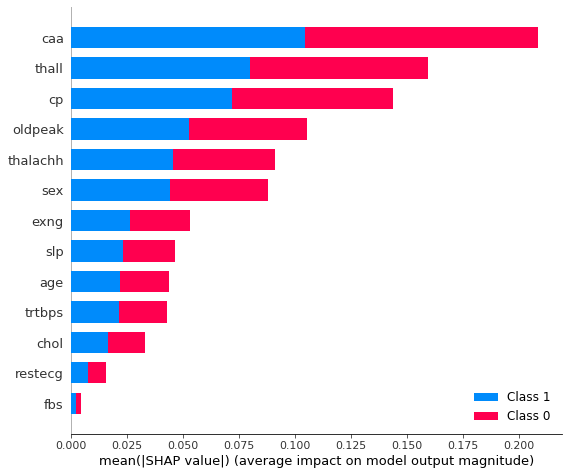

[interactive chart not shown]

The PVI is different from SHAP and GiniVI: the two latter explanations attribute a lot of weight to caa, which is less emphasised by PVI. Of course, those three metrics are qualitatively different proxies for feature importance, so we cannot expect them to give the same results. There are some general similarities, though: cp, caa and thall are all significant in all three methods. This might mean that, since the large attributions are present across different methods, the variables are good candidates for further investigation of their influence on the problem of prediction.